# Final Project v2

```python
import pandas as pd
import numpy as np
import seaborn as sn
import matplotlib.pyplot as plt
from sklearn import linear_model
from ast import literal_eval
```

## Introduction

Music in the last 100 years has gone through many drastic changes compared to the centuries prior. Much of this is due to the internet allowing people to share their music globally for free and the invention of many different electronic instruments such as the electric guitar, synths, sampler, and programmable drum machines. There is also much less of a rigid expectation of what a song should be which allows artists to experiment with new sounds and genres. This comes with benefits but also some negatives (if you want to do data science on music). The positives are pretty self explanatory such as: there is more variety and you don't need to be classically trained to create songs. From the data science perspective, it makes things much harder to categorize and quantify. Many songs are genre-blurring or can be created by sampling a completely different song. When it comes to digital audio workstations (ex: FL Studio), they can contain hundreds of libraries with thousands of different instruments that can be modulated many different ways. Legendary producer J Dilla pioneered turning off the quantization (https://en.wikipedia.org/wiki/Quantization_(music)) on his drum machine which caused the beat to not have a looping pattern. Things like these make music harder to analyze because of the expanding definition of what is music.

Thankfully, the Spotify API provides many in depth metrics to analyze music from the past 100 years. The dataset I used can be found here: https://www.kaggle.com/yamaerenay/spotify-dataset-19212020-160k-tracks. This Kaggle dataset contains six hundred thousand tracks (tracks.csv) and 1 million artists (artists.csv). There is an issue with the API where some of the dates are incorrect so I will try to avoid analyzing dates specifically due to the inaccuracy.

## Track Metrics:

acousticness: A confidence measure from 0.0 to 1.0 of whether the track is acoustic. 1.0 represents high confidence the track is acoustic.

danceability: Danceability describes how suitable a track is for dancing based on a combination of musical elements including tempo, rhythm stability, beat strength, and overall regularity. A value of 0.0 is least danceable and 1.0 is most danceable.

duration_ms: The duration of the track in milliseconds.

energy: Energy is a measure from 0.0 to 1.0 and represents a perceptual measure of intensity and activity. Typically, energetic tracks feel fast, loud, and noisy. Perceptual features contributing to this attribute include dynamic range, perceived loudness, timbre, onset rate, and general entropy.

id: The Spotify ID for the track.

instrumentalness: Predicts whether a track contains no vocals. “Ooh” and “aah” sounds are treated as instrumental in this context. Rap or spoken word tracks are clearly “vocal”. The closer the instrumentalness value is to 1.0, the greater likelihood the track contains no vocal content. Values above 0.5 are intended to represent instrumental tracks, but confidence is higher as the value approaches 1.0.

key: The key the track is in. Integers map to pitches using standard Pitch Class notation . E.g. 0 = C, 1 = C♯/D♭, 2 = D, and so on.

liveness: Detects the presence of an audience in the recording. Higher liveness values represent an increased probability that the track was performed live. A value above 0.8 provides strong likelihood that the track is live.

loudness: The overall loudness of a track in decibels (dB). Loudness values are averaged across the entire track and are useful for comparing relative loudness of tracks. Loudness is the quality of a sound that is the primary psychological correlate of physical strength (amplitude). Values typical range between -60 and 0 db.

mode: Mode indicates the modality (major or minor) of a track, the type of scale from which its melodic content is derived. Major is represented by 1 and minor is 0.

speechiness: Speechiness detects the presence of spoken words in a track. The more exclusively speech-like the recording (e.g. talk show, audio book, poetry), the closer to 1.0 the attribute value. Values above 0.66 describe tracks that are probably made entirely of spoken words. Values between 0.33 and 0.66 describe tracks that may contain both music and speech, either in sections or layered, including such cases as rap music. Values below 0.33 most likely represent music and other non-speech-like tracks.

tempo: The overall estimated tempo of a track in beats per minute (BPM). In musical terminology, tempo is the speed or pace of a given piece and derives directly from the average beat duration.

time_signature: An estimated overall time signature of a track. The time signature (meter) is a notational convention to specify how many beats are in each bar (or measure).

valence: A measure from 0.0 to 1.0 describing the musical positiveness conveyed by a track. Tracks with high valence sound more positive (e.g. happy, cheerful, euphoric), while tracks with low valence sound more negative (e.g. sad, depressed, angry).

## Artist Metrics:

followers: Information about the followers of the artist.

genres: A list of the genres the artist is associated with. For example: "Prog Rock" , "Post-Grunge". (If not yet classified, the array is empty.)

id: The Spotify ID for the artist.

name: The name of the artist.

popularity: The popularity of the artist. The value will be between 0 and 100, with 100 being the most popular. The artist’s popularity is calculated from the popularity of all the artist’s tracks.

name: The name of the artist.

## Motivation:

In the streaming and internet era, it is getting harder and harder for up and coming musicians to gain popularity and/or a fanbase. The competition pool has increased drastically due to the lesser barriers of entry. Before the internet, artists would have to pay (or the label) to create cassettes or records and then hope to get lucky by being played on the radio/MTV or opening for an established artist on tour. Now, all an artist needs to do is create a free soundcloud account and their music could go viral on social media (mostly without marketing in the traditional sense). This makes it so that each indiidual artist has a lesser chance of blowing up since there are way more people that can get into music. For this reason, I wanted to analyze the statistics of songs and artists to see if there is any way to figure which statistics matter most for making hit songs and which have little importance. If there is a large dependence on a certain variable being high/low and the song being popular, it could help small time musicians create tracks that are statistically more likely to be popular.

```python
#Creates pandas dataframe from Comma Seperated Value table of tracks
tracks = pd.read_csv('tracks.csv')
#Limits amount of rows shown in output
pd.set_option('display.max_rows', 100)
```

```python
tracks
```

|  | id | name | popularity | duration_ms | explicit | artists | id_artists | release_date | danceability | energy | key | loudness | mode | speechiness | acousticness | instrumentalness | liveness | valence | tempo | time_signature |
| --- | --- | --- | --- | --- | --- | --- | --- | --- | --- | --- | --- | --- | --- | --- | --- | --- | --- | --- | --- | --- |
| 0 | 35iwgR4jXetI318WEWsa1Q | Carve | 6 | 126903 | 0 | ['Uli'] | ['45tIt06XoI0Iio4LBEVpls'] | 1922-02-22 | 0.645 | 0.4450 | 0 | -13.338 | 1 | 0.4510 | 0.674 | 0.744000 | 0.1510 | 0.1270 | 104.851 | 3 |
| 1 | 021ht4sdgPcrDgSk7JTbKY | Capítulo 2.16 - Banquero Anarquista | 0 | 98200 | 0 | ['Fernando Pessoa'] | ['14jtPCOoNZwquk5wd9DxrY'] | 1922-06-01 | 0.695 | 0.2630 | 0 | -22.136 | 1 | 0.9570 | 0.797 | 0.000000 | 0.1480 | 0.6550 | 102.009 | 1 |
| 2 | 07A5yehtSnoedViJAZkNnc | Vivo para Quererte - Remasterizado | 0 | 181640 | 0 | ['Ignacio Corsini'] | ['5LiOoJbxVSAMkBS2fUm3X2'] | 1922-03-21 | 0.434 | 0.1770 | 1 | -21.180 | 1 | 0.0512 | 0.994 | 0.021800 | 0.2120 | 0.4570 | 130.418 | 5 |
| 3 | 08FmqUhxtyLTn6pAh6bk45 | El Prisionero - Remasterizado | 0 | 176907 | 0 | ['Ignacio Corsini'] | ['5LiOoJbxVSAMkBS2fUm3X2'] | 1922-03-21 | 0.321 | 0.0946 | 7 | -27.961 | 1 | 0.0504 | 0.995 | 0.918000 | 0.1040 | 0.3970 | 169.980 | 3 |
| 4 | 08y9GfoqCWfOGsKdwojr5e | Lady of the Evening | 0 | 163080 | 0 | ['Dick Haymes'] | ['3BiJGZsyX9sJchTqcSA7Su'] | 1922 | 0.402 | 0.1580 | 3 | -16.900 | 0 | 0.0390 | 0.989 | 0.130000 | 0.3110 | 0.1960 | 103.220 | 4 |
| ... | ... | ... | ... | ... | ... | ... | ... | ... | ... | ... | ... | ... | ... | ... | ... | ... | ... | ... | ... | ... |
| 586667 | 5rgu12WBIHQtvej2MdHSH0 | 云与海 | 50 | 258267 | 0 | ['阿YueYue'] | ['1QLBXKM5GCpyQQSVMNZqrZ'] | 2020-09-26 | 0.560 | 0.5180 | 0 | -7.471 | 0 | 0.0292 | 0.785 | 0.000000 | 0.0648 | 0.2110 | 131.896 | 4 |
| 586668 | 0NuWgxEp51CutD2pJoF4OM | blind | 72 | 153293 | 0 | ['ROLE MODEL'] | ['1dy5WNgIKQU6ezkpZs4y8z'] | 2020-10-21 | 0.765 | 0.6630 | 0 | -5.223 | 1 | 0.0652 | 0.141 | 0.000297 | 0.0924 | 0.6860 | 150.091 | 4 |
| 586669 | 27Y1N4Q4U3EfDU5Ubw8ws2 | What They'll Say About Us | 70 | 187601 | 0 | ['FINNEAS'] | ['37M5pPGs6V1fchFJSgCguX'] | 2020-09-02 | 0.535 | 0.3140 | 7 | -12.823 | 0 | 0.0408 | 0.895 | 0.000150 | 0.0874 | 0.0663 | 145.095 | 4 |
| 586670 | 45XJsGpFTyzbzeWK8VzR8S | A Day At A Time | 58 | 142003 | 0 | ['Gentle Bones', 'Clara Benin'] | ['4jGPdu95icCKVF31CcFKbS', '5ebPSE9YI5aLeZ1Z2g... | 2021-03-05 | 0.696 | 0.6150 | 10 | -6.212 | 1 | 0.0345 | 0.206 | 0.000003 | 0.3050 | 0.4380 | 90.029 | 4 |
| 586671 | 5Ocn6dZ3BJFPWh4ylwFXtn | Mar de Emociones | 38 | 214360 | 0 | ['Afrosound'] | ['0i4Qda0k4nf7jnNHmSNpYv'] | 2015-07-01 | 0.686 | 0.7230 | 6 | -7.067 | 1 | 0.0363 | 0.105 | 0.000000 | 0.2640 | 0.9750 | 112.204 | 4 |

586672 rows × 20 columns

The reason why we turn the strings with the date into datetime objects is that it will be easier to process down the line. Datetime objects can be processed numerically unlike strings. There are some dates that only have the year so we will have them fall on the first day of that year as a placeholder. The tracks column needs to be renamed to avoid conflicts with looking up the inde of a row.

```python
#Turns strings from release_date into datetime objects
tracks['release_date'] = pd.to_datetime(tracks['release_date'])
#Rename name of track column to title since tracks.name is also the way of getting the index
tracks = tracks.rename(columns={"name": "title"})
tracks
```

[output not shown]

```python
#Creates pandas dataframe from Comma Seperated Value table of artists
artists = pd.read_csv('artists.csv')
#Shows all columns with NaN values
artists[artists.isna().any(axis=1)]
```

|  | id | followers | genres | name | popularity |
| --- | --- | --- | --- | --- | --- |
| 444199 | 7F71W80jaXFARK7hBjsDI2 | NaN | ['czech pop'] | Marcell | 36 |
| 444200 | 3MLHJz04KmEVzCTPclzkEm | NaN | ['czech pop'] | Niko | 21 |
| 444797 | 0cqZsULDZdJTGA4Zqh8Ckv | NaN | [] | Savzilla | 0 |
| 444798 | 0BuknWzKujyc9HfZ1V50Uk | NaN | [] | Duck Doja | 0 |
| 446635 | 6ltU5gIDLmWNYaVNHnll5G | NaN | ['mexican electronic'] | Zofa | 0 |
| 446636 | 7C9nWRMbRqpPUuKh2OEw9n | NaN | [] | MHV | 3 |
| 446637 | 41c30F8zy5UCTSevbn0WfD | NaN | ['mexican electronic'] | Broadband Star | 0 |
| 468525 | 1DK979aOesiZ4Vkus8txqu | NaN | [] | AmorArtis Orchestra & Johannes Somary | 2 |
| 468526 | 6jkpqSWWsXSuqtsoeAiMDU | NaN | ['uk americana'] | Police Dog Hogan | 14 |
| 468527 | 7aMdHPv79qOuqqBD6TnaCp | NaN | [] | Miles Davis & Charlie "Bird" Parker | 0 |
| 468528 | 2lr0R5vHGfI0C489h0r6qV | NaN | ['dc indie'] | Black Dog Prowl | 16 |
| 468529 | 0xkSOIeyeTILNIOZKyFgaP | NaN | [] | Band of the Fifteenth Field Artillery Regiment... | 3 |
| 468530 | 4EqqnE0XMAcreVF84QGYJ0 | NaN | [] | Robert Steven Williams | 0 |

Below we drop every row with a NaN value or no genres. This is because there arent many rows with NaN values and there are about 300,000 artists with genres which is plenty to do analysis on pupular artists. There are not many other significant columns so I chose to prioritize genres (popularity and followers are usually there if an artist has classified genres).

```python
#Drops all rows with NaN values
artists = artists.dropna()
```

```python
#Creates new dataframe with all of the rows from artist that have a genre classification
artists_genres = artists[artists.astype(str)['genres'] != '[]']
artists_genres
```

|  | id | followers | genres | name | popularity |
| --- | --- | --- | --- | --- | --- |
| 45 | 0VLMVnVbJyJ4oyZs2L3Yl2 | 71.0 | ['carnaval cadiz'] | Las Viudas De Los Bisabuelos | 6 |
| 46 | 0dt23bs4w8zx154C5xdVyl | 63.0 | ['carnaval cadiz'] | Los De Capuchinos | 5 |
| 47 | 0pGhoB99qpEJEsBQxgaskQ | 64.0 | ['carnaval cadiz'] | Los “Pofesionales” | 7 |
| 48 | 3HDrX2OtSuXLW5dLR85uN3 | 53.0 | ['carnaval cadiz'] | Los Que No Paran De Rajar | 6 |
| 136 | 22mLrN5fkppmuUPsHx6i2G | 59.0 | ['classical harp', 'harp'] | Vera Dulova | 3 |
| ... | ... | ... | ... | ... | ... |
| 1104328 | 1q9C5XlekzXbRLIuLCDTre | 90087.0 | ['social media pop', 'teen pop'] | Brent Rivera | 33 |
| 1104331 | 4fh2BIKYPFvXFsQLhaeVJp | 309.0 | ['la indie'] | Lone Kodiak | 20 |
| 1104334 | 7akMsd2vb4xowNTehv3gsY | 774.0 | ['indie rockism'] | The Str!ke | 0 |
| 1104336 | 35m7AJrUCtHYHyIUhCzmgi | 205.0 | ['indie rockism'] | Hunter Fraser | 6 |
| 1104345 | 1ljurfXKPlGncNdW3J8zJ8 | 2123.0 | ['deep acoustic pop'] | Right the Stars | 18 |

298610 rows × 5 columns

The different types of data are ordinal, ratio, nominal, and interval. Since all of the numerical statistics have a true zero and the order matters, they are ratio. Pearson correlation matrices are the best type for ratio data so that is why I chose this type. For more information on the types of data: https://www.graphpad.com/support/faq/what-is-the-difference-between-ordinal-interval-and-ratio-variables-why-should-i-care/ and the types of correlation matrices: https://ademos.people.uic.edu/Chapter22.html check out these links. From this matrix we can see that the highest correlation between popularity and another metric can be found with energy, loudness, and accousticness (negative correlation).

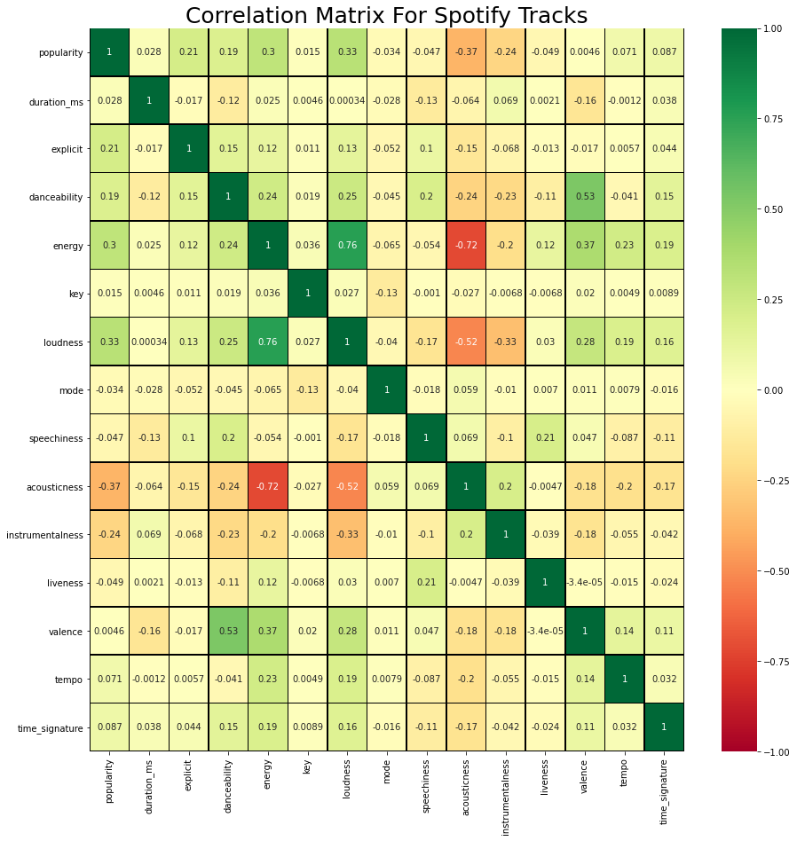

```python
#Sets size of plot
plt.subplots(figsize = (15,15))

#Creates correlation matrix using pearson method
correlation_matrix = tracks.corr('pearson')

#Creates heatmap with correlation matrix using seaborn library
ax = sn.heatmap(correlation_matrix, annot = True, vmin = -1, vmax = 1, cmap = 'RdYlGn', linewidths=.5, linecolor = 'Black')
ax.set_title('Correlation Matrix For Spotify Tracks', fontsize=25)
plt.show()
```

From a glance this plot below may look randomly distributed but this is due to the many songs with zero popularity. If we were to normalize this graph, the correlation would be easier to notice.

```
Best fit intercept: 15.620689480330746
Best fit slope: 22.045331804948134
```

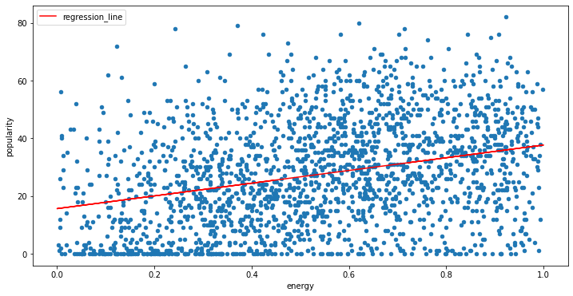

```python
#Taking a random sample of 2000 rows for the scatter plot so it is possible to see the individual dots
tracks_sample1 = tracks.sample(n = 2000, random_state = 1)
#Create scatter plot with energy as x axis and popularity as y axis
ax = tracks_sample1.plot(x = ['energy'], y = ['popularity'], kind = 'scatter', figsize = (12, 6))
#Calculates slope and y-intercept of line of best fit (regression) for entire tracks dataframe (not sample)
m, b = np.polyfit(tracks['energy'], tracks['popularity'], 1)
#Adds column with y value for regression based on the current x (energy)
tracks['regression_line'] = m * tracks['energy'] + b
#Adds best fit line on top of scatter plot
ax1 = tracks.plot(x = 'energy', y = 'regression_line', ax = ax, color = 'red', ylabel = 'popularity')
print("Best fit intercept: " + str(b) + "\nBest fit slope: " + str(m))
```

```
Best fit intercept: 39.61784737222383
Best fit slope: 1.1804542166323209
```

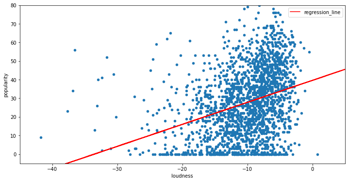

```python
#Taking a random sample of 2000 rows for the scatter plot so it is possible to see the individual dots
tracks_sample1 = tracks.sample(n = 2000, random_state = 1)
#Create scatter plot with loudness as x axis and popularity as y axis
ax = tracks_sample1.plot(x = ['loudness'], y = ['popularity'], kind = 'scatter', figsize = (12, 6))
#Calculates slope and y-intercept of line of best fit (regression) for entire tracks dataframe (not sample)
m, b = np.polyfit(tracks['loudness'], tracks['popularity'], 1)
#Adds column with y value for regression based on the current x (loudness)
tracks['regression_line'] = m * tracks['loudness'] + b
#Adds best fit line on top of scatter plot
ax1 = tracks.plot(x = 'loudness', y = 'regression_line', ax = ax, color = 'red',
                  xlim = (-45, 5), ylim = (-5,80), ylabel = 'popularity')
print("Best fit intercept: " + str(b) + "\nBest fit slope: " + str(m))
```

```
Best fit intercept: 36.35658571475897
Best fit slope: -19.531587004243235
```

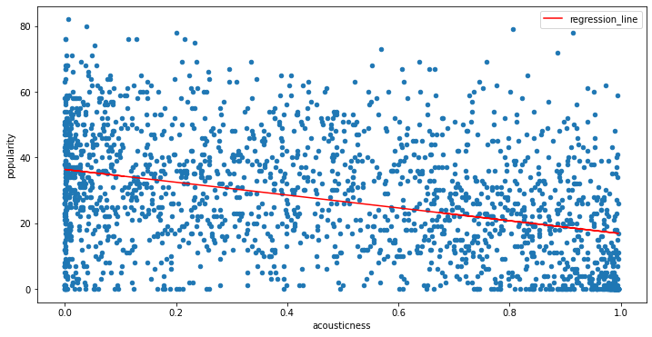

```python
#Taking a random sample of 2000 rows for the scatter plot so it is possible to see the individual dots
tracks_sample1 = tracks.sample(n = 2000, random_state = 1)
#Create scatter plot with acousticness as x axis and popularity as y axis
ax = tracks_sample1.plot(x = ['acousticness'], y = ['popularity'], kind = 'scatter', figsize = (12, 6))
#Calculates slope and y-intercept of line of best fit (regression) for entire tracks dataframe (not sample)
m, b = np.polyfit(tracks['acousticness'], tracks['popularity'], 1)
#Adds column with y value for regression based on the current x (acousticness)
tracks['regression_line'] = m * tracks['acousticness'] + b
#Adds best fit line on top of scatter plot
ax1 = tracks.plot(x = 'acousticness', y = 'regression_line', ax = ax, color = 'red', ylabel = 'popularity')
print("Best fit intercept: " + str(b) + "\nBest fit slope: " + str(m))
```

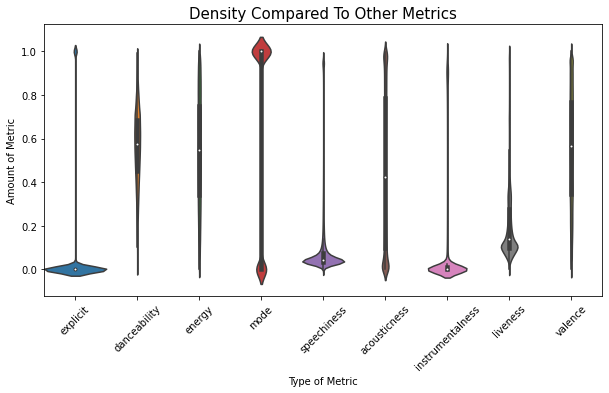

```python
#Scale is equal so you can compare one variables violin plot with another.

#Sets size of plot
plt.subplots(figsize = (10,5))

#Creates violin plot (density per metric per value is thickness of violin)
sn.violinplot(data=tracks[['explicit', 'danceability', 'energy', 'mode', 'speechiness', 'acousticness', 'instrumentalness','liveness',
                           'valence']], width=1, showmeans=True).set_title('Density Compared To Other Metrics', fontsize=15)
#Changes labels their orientation in the plot
plt.ylabel('Amount of Metric')
plt.xlabel('Type of Metric')
plt.xticks(rotation=45)
plt.show()
```

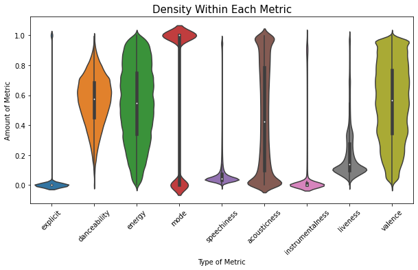

```python
#Width same at peaks but density not

#Sets size of plot
plt.subplots(figsize = (10,5))

#Creates violin plot (density per metric per value is thickness of violin)
ax = sn.violinplot(data=tracks[['explicit', 'danceability', 'energy', 'mode', 'speechiness', 'acousticness',
                           'instrumentalness','liveness', 'valence']], scale='width', showmeans=True)
#Changes labels their orientation in the plot
ax.set_title('Density Within Each Metric', fontsize=15)
plt.xticks(rotation=45)
plt.ylabel('Amount of Metric')
plt.xlabel('Type of Metric')
plt.show()
```

```python
#Create empty dictionary
genre_dict = {}
#For every artists with a genre
for i in artists_genres.genres:
    #Split list up by commas
    lst = i.split(',')
    #If list only has one genre it must be sliced a certain way
    if(len(lst) == 1):
        #Checks if in dict, if not adds it
        if genre_dict.get(lst[0][2:-2]) == None:
            #Takes away unneeded apostrophes and brackets, adds to dict
            genre_dict.update({lst[0][2:-2]: 1})
        else:
            #Increments dict value
            genre_dict.update({lst[0][2:-2]: genre_dict.get(lst[0][2:-2]) + 1})
    #Handles lists with multiple genres
    else:
        for i in range(0, len(lst)):
            #Last genre in list must be sliced a certain way
            if i == len(lst):
                if genre_dict.get(lst[0][2:-2]) == None:
                    genre_dict.update({lst[0][2:-2]: 1})
                else:
                    genre_dict.update({lst[0][2:-2]: genre_dict.get(lst[0][2:-2]) + 1})
            #Slicing for every other element
            else:
                if genre_dict.get(lst[0][2:-1]) == None:
                    genre_dict.update({lst[0][2:-1]: 1})
                else:
                    genre_dict.update({lst[0][2:-1]: genre_dict.get(lst[0][2:-1]) + 1})
#Turns dict into series with two named columns
ser = pd.Series(genre_dict, name='Count')
ser.index.name = 'Genre'
#Reindexes series
ser.reset_index()
#Converts series to dataframe
genre_df = pd.DataFrame(ser)
#Sorts counts in descending order
genre_df = genre_df.sort_values(by = 'Count', ascending=False)
genre_df
```

| Genre | Count |
| --- | --- |
| album rock | 2366 |
| dance pop | 1931 |
| adult standards | 1900 |
| alternative metal | 1796 |
| alternative dance | 1573 |
| ... | ... |
| singer-songwriter | 1 |
| sierreno | 1 |
| viking metal | 1 |
| metal baiano | 1 |
| thrash metal | 1 |

5361 rows × 1 columns

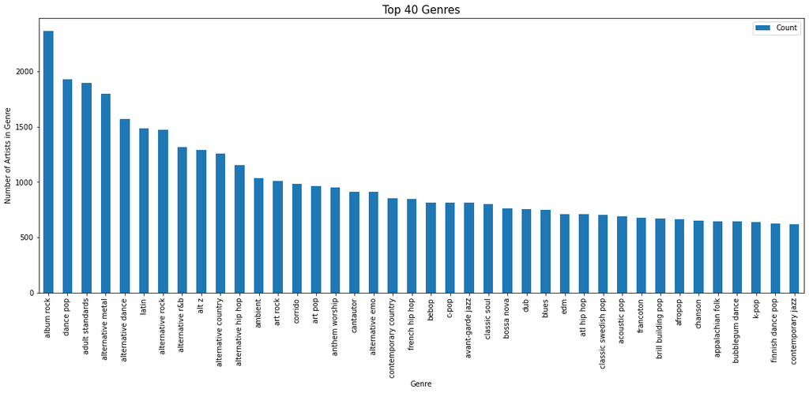

```python
#New dataframe with 40 most common genres
first_40 = genre_df.head(40)
#Makes bar plot with pandas
first_40.plot(kind='bar', figsize=(19,7))
plt.xticks(rotation=90)
plt.title('Top 40 Genres', fontsize=15)
plt.ylabel('Number of Artists in Genre')
plt.show()
```

In conlusion, the best predictors of popularity are energy, loudness, and accousticness. Energy is uniformly distributed while accouticness is concentrated at both the top and the bottom of the scale. Out of all of the genres listed in the API, Album Rock has the most artists meaning that if you want the best chance of getting on Spotify, you should try to create music in this genre.